# Decomposition and ARIMA

## Multiple Season Effect Decomposition

Since both hour and day effect is observable, it is need to be handled separately, therefore, I used multiple seasonal decomposition method based on 24 and 24*7 frequency.

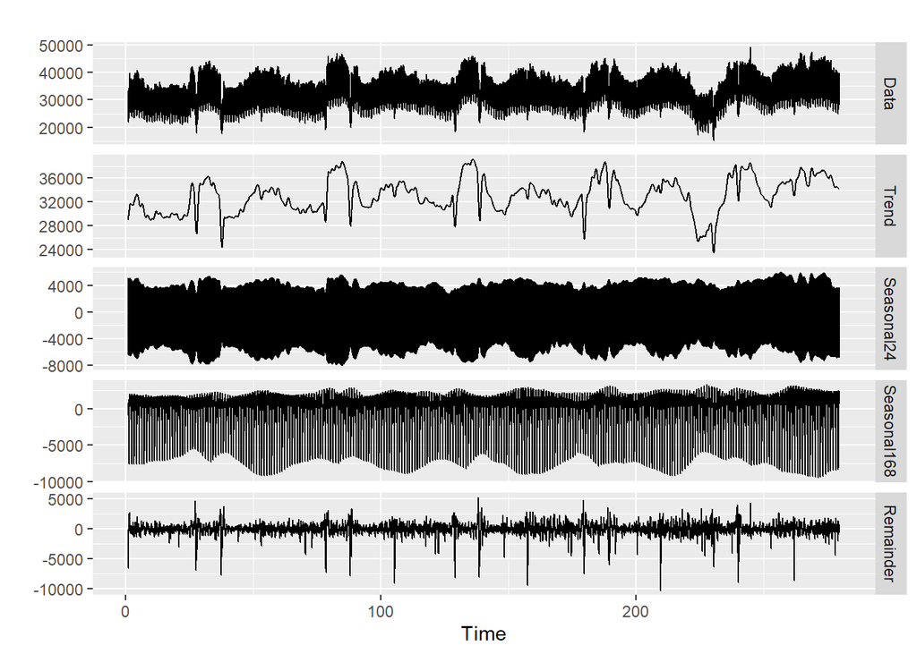

```
## [1] "Multiple Seasonal Effect Method"
```

```
##
## #######################################
## # KPSS Unit Root / Cointegration Test #
## #######################################
##
## The value of the test statistic is: 0.0024
```

It is seen that the method separate two seasonal compomnents and get a more stationary serie than additive model.

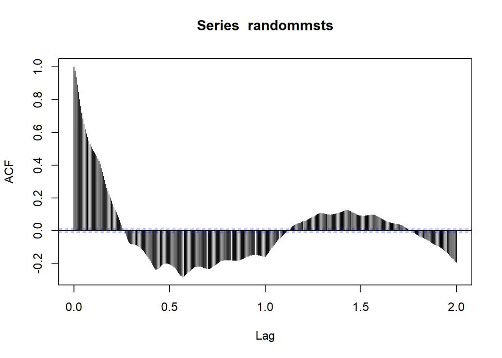

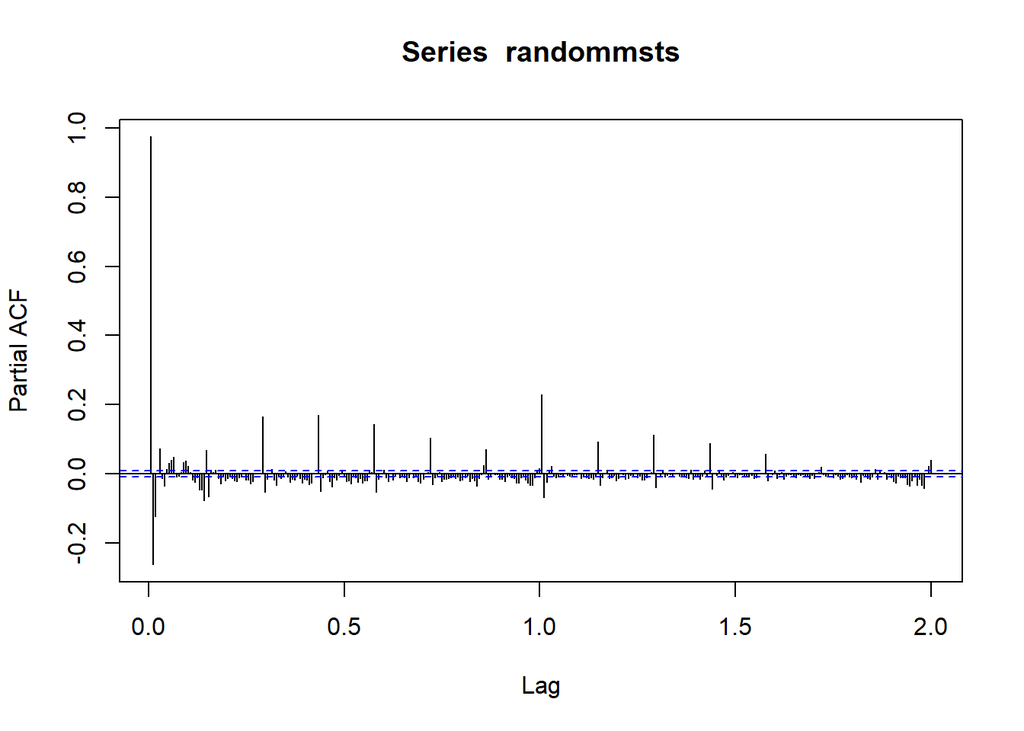

the ACF shows exponential decreasing behavior which shows that season effect is less than additive method and Partial autocorrelation values decreased. I will continue to my model by using multiple seasonal effect decomposition method.Moreover, the PACF is not increase significantly after lag 1, therefore the autoregressive model can be more suitable.It shows that data has the effect of early observations , however, when the relationships of intervening observations removed, correlation between previous observations is not too high since partical autocorrelation is not high.

## ARIMA Models

In this part of report, different AR and MA models will be tried to get better fit model based on AIC values.

When the ACF and PACF plots are examined , ACF is geometrically decaying and there is a spkie at lag 1 in PACF, therefore I think AR model (autoregressive model) can be more suitable with p = 1, however I will try different models and select a model by considering their AIC values.

### Autoregressive Model

The value of different AR(p) models is listed below, the AIC values decreasing when p value is increasing and I stopped to try at 9 since the decrease in AIC values is geting smaller and model complexity is increasing. If I construct an Autoreggressive Model, I choose p = 3 because at p=4 AIC increase and the decrease in AIC values is negligible and p = 3 is relatively simple model.

```
## [1] " in model order = ( 1 0 0 ) AIC =  629683.494300767"
## [1] " in model order = ( 2 0 0 ) AIC =  626328.293080348"
## [1] " in model order = ( 3 0 0 ) AIC =  625605.669913894"
## [1] " in model order = ( 4 0 0 ) AIC =  625607.231495005"
## [1] " in model order = ( 5 0 0 ) AIC =  625361.402385835"
## [1] " in model order = ( 6 0 0 ) AIC =  625355.22428821"
## [1] " in model order = ( 7 0 0 ) AIC =  625297.118523586"
## [1] " in model order = ( 8 0 0 ) AIC =  625289.616118777"
## [1] " in model order = ( 9 0 0 ) AIC =  625249.273792842"
```

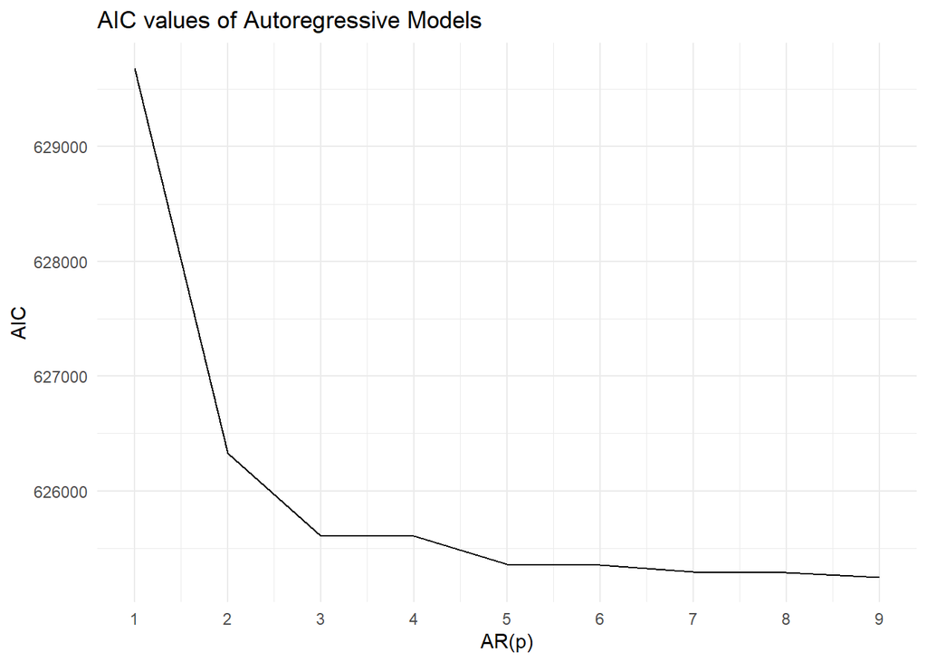

### Moving Average

By examining ACF and PACF plot of the consumption Data and AIC values of MA models,AR is seems more suitable model.

```
## [1] " in model order = ( 0 0 1 ) AIC =  717223.52913816"
## [1] " in model order = ( 0 0 2 ) AIC =  685034.282117835"
## [1] " in model order = ( 0 0 3 ) AIC =  663895.034834206"
## [1] " in model order = ( 0 0 4 ) AIC =  651081.118720111"
## [1] " in model order = ( 0 0 5 ) AIC =  643604.272413447"
## [1] " in model order = ( 0 0 6 ) AIC =  638346.160209104"
## [1] " in model order = ( 0 0 7 ) AIC =  635832.759724103"
## [1] " in model order = ( 0 0 8 ) AIC =  633792.60841642"
## [1] " in model order = ( 0 0 9 ) AIC =  631246.095693079"
```

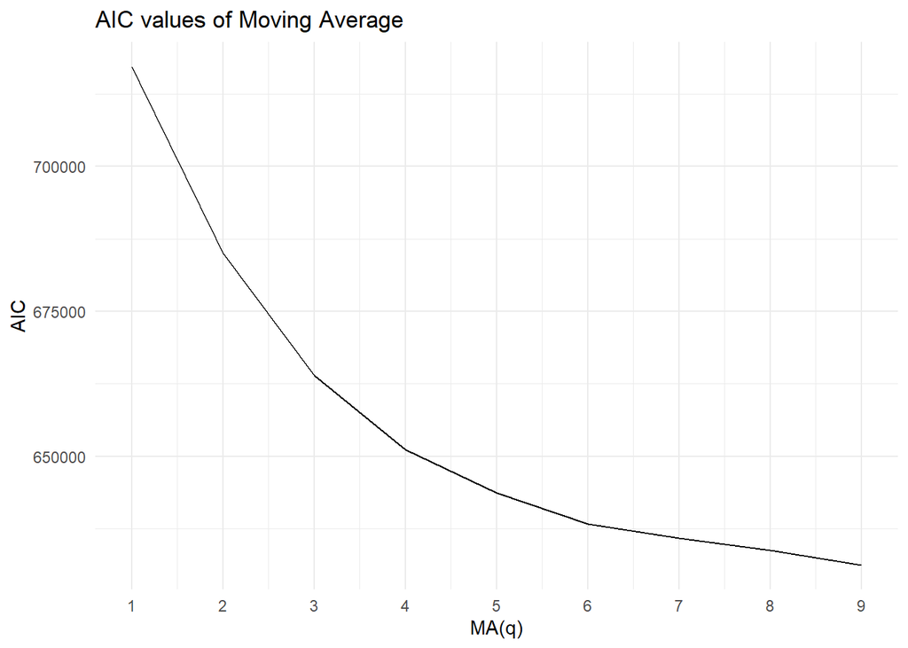

### ARIMA

At first,if the model needs differencing checked by ndiffs() function.

```
## [1] " # of differencing needed is 0"
```

Since the data do not require differencing d = 0, and different combination of p and q is tried and results are given below.

```
##    1,0,1    2,0,1    1,0,2    2,0,1    2,0,2    3,0,2    2,0,3    3,0,3
## 627105.3 625778.6 625811.5 625778.6 625506.0 625393.1 625317.4 625296.3
##    1,0,3
## 625342.7
```

arima( 3,0,3) has the lowest AIC value.

### Model Selection

```
##         AIC Models
## 1: 625296.3  3,0,3
```

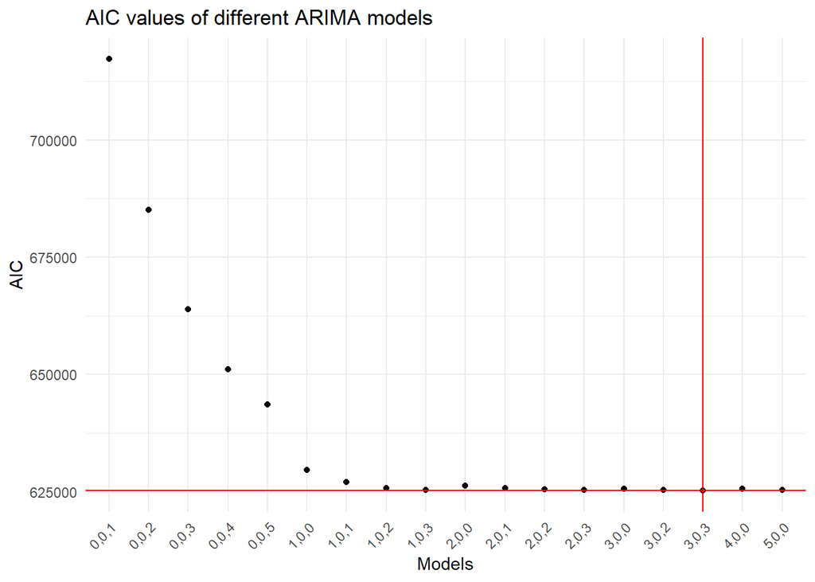

### Resiudal Analysis

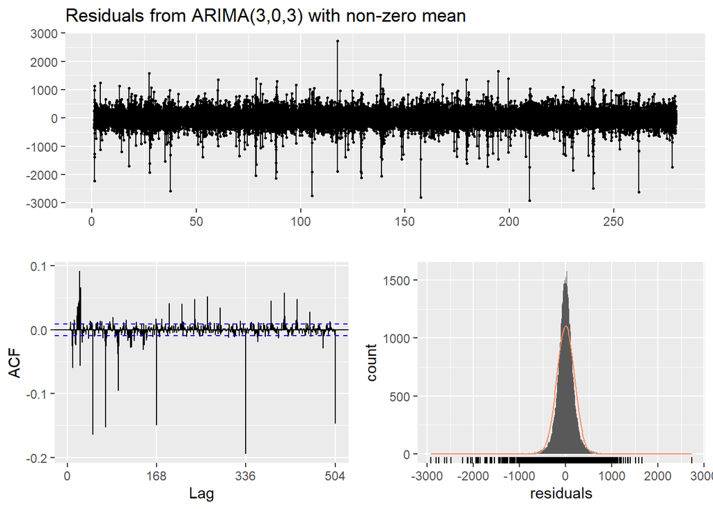

```
##
##  Ljung-Box test
##
## data:  Residuals from ARIMA(3,0,3) with non-zero mean
## Q* = 8442.5, df = 329, p-value < 2.2e-16
##
## Model df: 7.   Total lags used: 336
```

```
## [1] 0.01383166
```

The fitted values of model and the actual values are plotted below to see more clearly the performance of model.

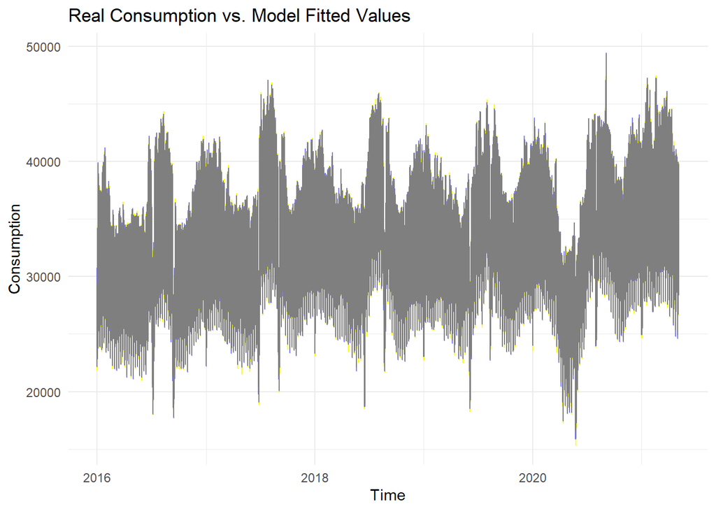

## Forecast

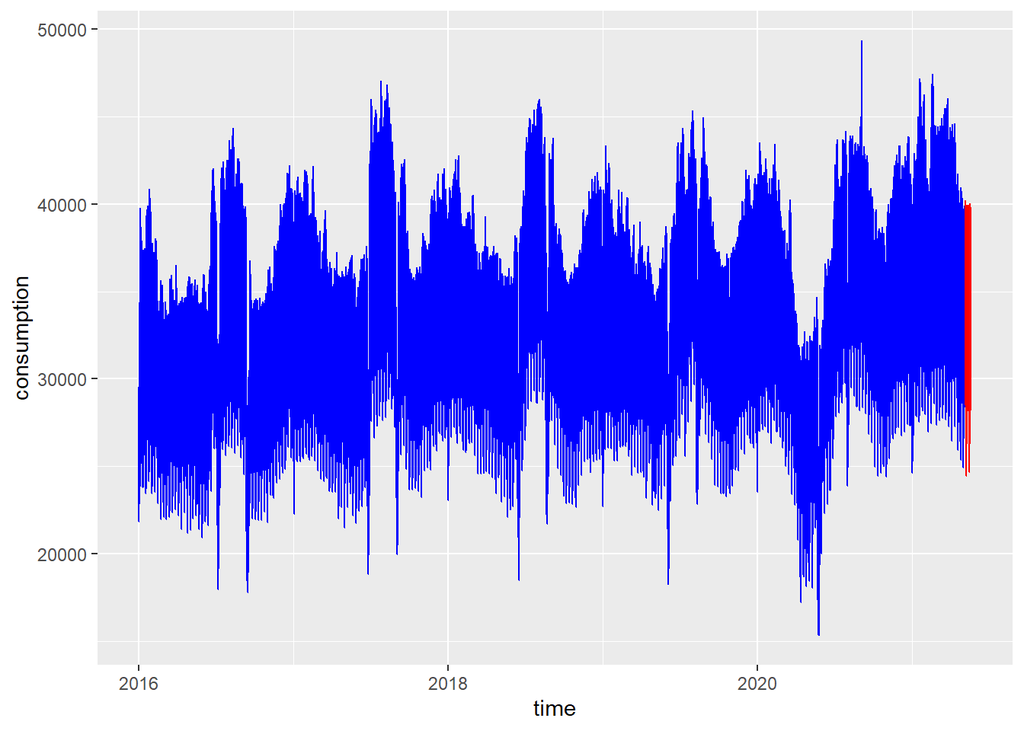

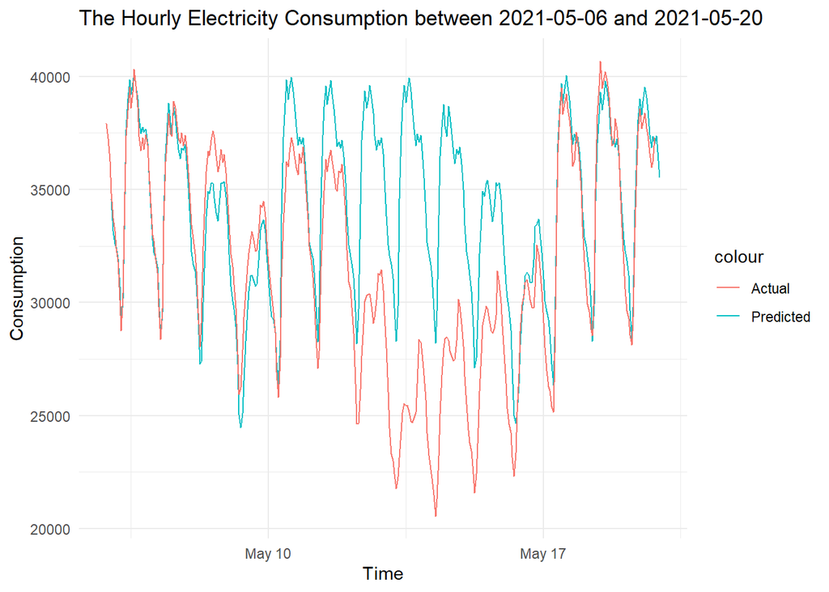

### Daily Consumption

The daily mean consumption is calculated and plotted below.

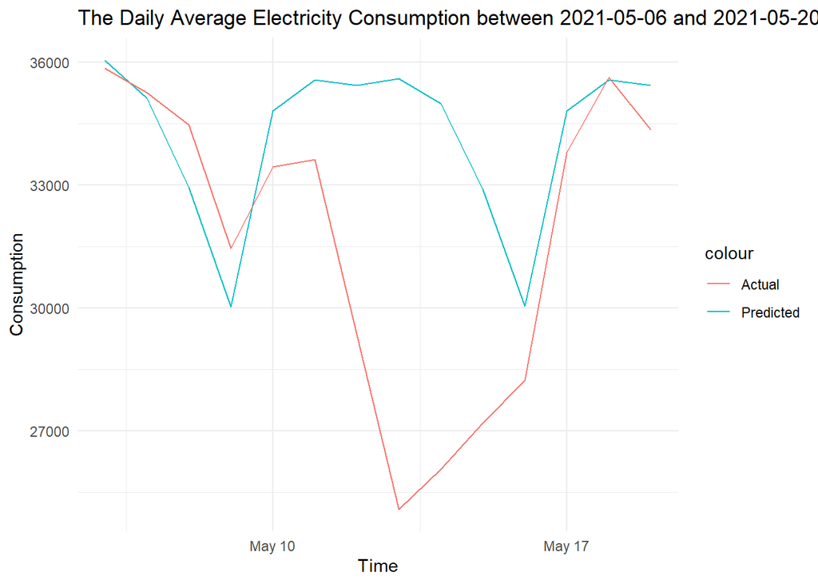

### model evaluation

```
##    n     mean      sd        CV       FBias      MAPE     RMSE      MAD
## 1 13 31380.18 3718.18 0.1184882 -0.08839641 0.1416637 5198.698 4002.809
##        MADP     WMAPE
## 1 0.1275585 0.1275585
```

It can be said that between May 10 and May 17 model can not successfully forecast, however, during this time in Turkey religion holiday was celebrated, and the religion holiday is determined according to islamic calendar and model is weak the find effect of holiday.

## Conslusion

In conclusion, at first the data is analized overall. It is checked that if there are seasonality, trend or unusual patterns. The Hour, Day , and month effect is clearly observable. Moreover, the behavior of data in summer and winter shows that temperature can has effect on the consumption. Some special events and holidays data shows different pattern from the usual one. By adding, effects of different factors model can be improved.

## References

[EPIAS](https://seffaflik.epias.com.tr/transparency/tuketim/gerceklesen-tuketim/gercek-zamanli-tuketim.xhtml)

[Forecasting: Principles and Practice](https://otexts.com/fpp2/)

and suplemantary codes from Boun IE 360 Spring 2021 class by Mustafa Baydoğan

# RMD

The code of my study is available from [here](https://bu-ie-360.github.io/spring21-seymacakir/files/homework-3/homework-3.Rmd)